# QTM 150 - Final Project

Jessica Kang

December 10th, 2018

## Does more expensive food mean better food? Does a price increase from lunch to dinner lead to a ratings increase?

### Why these questions?

Since the semester started, I’ve gone out to eat multiple times. As college students on a budget, my friends and I try to find restaurants that have a good balance between quality of food and price each time we eat out. Thus, I was curious whether restaurants with more expensive food and overall higher price ranges have better ratings. Should we choose a more expensive place to eat at in order to get better food or can we choose a cheaper place without sacrificing food quality? In addition, my friends and I usually go out for dinner, but dinner tends to be more expensive than lunch. I wanted to find out whether this increase in the price of food from lunch to dinner meant higher dinner than lunch ratings. Is it worth it to go to a restaurant for dinner or should I just go for lunch?

## Section 1: Original Data - Restaurant Survey Responses: Average Price vs Rating

For the first section, I sent out a survey to my friends asking them to list at least two of their favorite restaurants (excluding fast food places) and what they would rate each restaurant out of 5. I received 13 responses with 27 unique restaurants. For restaurants that were repeated, I took the average of the ratings. I then looked up the menu for each of these 27 restaurants and found the average of their cheapest and most expensive entrees to determine the average price for each restaurant. I saved this information as the `friendsrest` data frame. I then created a scatterplot to visualize the data and calculated R and R^2 to determine the strength of the relationship between average price and rating.

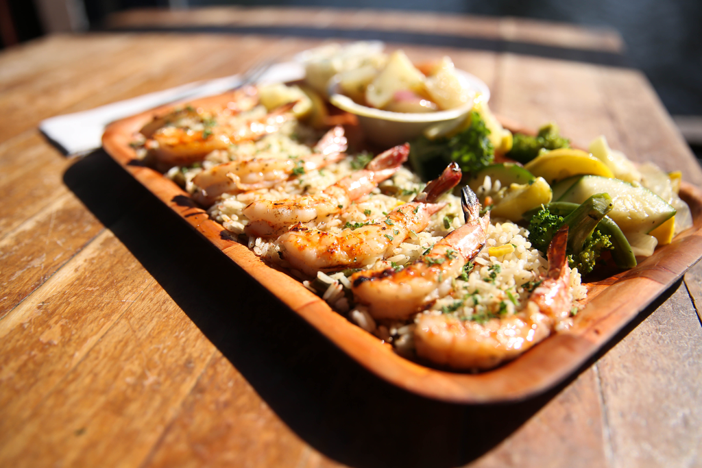

Food from the *Rustic Inn Restaurant*, the restaurant with the highest average price out of my friends’ responses

#### *Data Frame*

The data frame was created on Excel using my friends’ survey responses. The data frame includes the following: restaurant name, rating, lowest priced entree, highest priced entree, and average price.

```r
friendsrest <- read.csv("https://github.com/jkang4/QTM-150-Final-Project/blob/master/Favorite%20Restaurants%20-%20Responses.csv?raw=true")
```

#### **Data Visualization**

I created a scatterplot of rating vs average price with a best fit linear regression model.

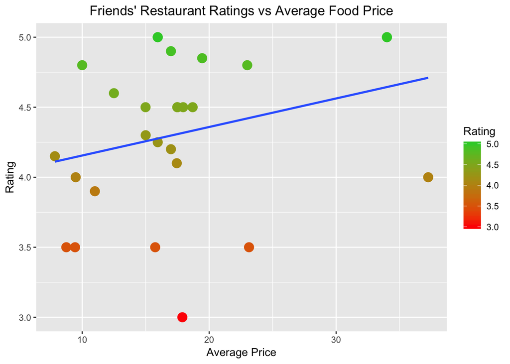

```r
ggplot(friendsrest, aes(x=Average_Price, y=Rating))+
  geom_point(size=4, aes(color=Rating))+
  scale_color_gradient(name="Rating", low="red", high="#32cd32")+
  labs(x="Average Price", y="Rating", title="Friends' Restaurant Ratings vs Average Food Price")+
  theme(plot.title = element_text(hjust = 0.5))+
  geom_smooth(method="lm", se = FALSE)
```

```r
lm(friendsrest$Average_Price ~ friendsrest$Rating)
```

```
##
## Call:
## lm(formula = friendsrest$Average_Price ~ friendsrest$Rating)
##
## Coefficients:
##        (Intercept)  friendsrest$Rating
##              1.830               3.653
```

*Correlation (R):*

The correlation between average price and rating of the restaurants from the survey is 0.2728, which indicates a weak, positive linear relationship.

```r
friendsrest %>%
  summarize(r_1 = cor(Average_Price, Rating))
```

```
##         r_1
## 1 0.2728147
```

*Coefficient of Determination (R^2):*

The percentage in variation of the data that is explained by the linear model is only %7.44, which indicates that the linear model is not a good fit.

```r
lm_fr <- lm(Average_Price ~ Rating, data = friendsrest)
summary(lm_fr)
```

```
##
## Call:
## lm(formula = Average_Price ~ Rating, data = friendsrest)
##
## Residuals:
##     Min      1Q  Median      3Q     Max
## -9.3637 -4.6102 -0.7779  0.8892 20.8086
##
## Coefficients:
##             Estimate Std. Error t value Pr(>|t|)
## (Intercept)    1.830     11.191   0.164    0.871
## Rating         3.653      2.576   1.418    0.169
##
## Residual standard error: 7.321 on 25 degrees of freedom
## Multiple R-squared:  0.07443,    Adjusted R-squared:  0.0374
## F-statistic:  2.01 on 1 and 25 DF,  p-value: 0.1686
```

```r
summary(lm_fr)$r.squared
```

```
## [1] 0.07442787
```

## Section 2: Experimental Procedures and Data Collection

For this section, I used an external dataset I found of [Kyoto Restaurant Reviews](https://www.kaggle.com/koki25ando/tabelog-restaurant-review-dataset) on Kaggle, which included information for 895 restaurants in Kyoto. I then generated a random sample of 80 restaurants that have numerical (non-NA) values for dinner and lunch prices as well as dinner and lunch ratings (results are hidden).

```r
Kyoto_Restaurant_Info <- read.csv("https://github.com/jkang4/QTM-150-Final-Project/blob/master/Kyoto_Restaurant_Info.csv?raw=true")
```

```r
rest <- Kyoto_Restaurant_Info[complete.cases(Kyoto_Restaurant_Info$LunchPrice, Kyoto_Restaurant_Info$DinnerPrice, Kyoto_Restaurant_Info$DinnerRating, Kyoto_Restaurant_Info$LunchRating),]
str(rest)

set.seed(12)
rest1<-rest[sample(1:nrow(rest),80, replace=FALSE),]
rest1
str(rest1)
```

### Part 1: Does More Expensive Food Mean Better Food? (Average Prices vs Overall Rating)

Part 1 of this section looks at the relationship between average prices and ratings for the sample of 80 Japanese restaurants. After changing the prices from factor to numeric vectors, I replaced the price intervals with the interval midpoints in the new `dinnerprice` and `lunchprice` numeric vectors. The average price for each of the 80 restaurants was calculated by taking the mean of each restaurant’s respective lunch and dinner prices. I then created a data frame that included average price and total rating.

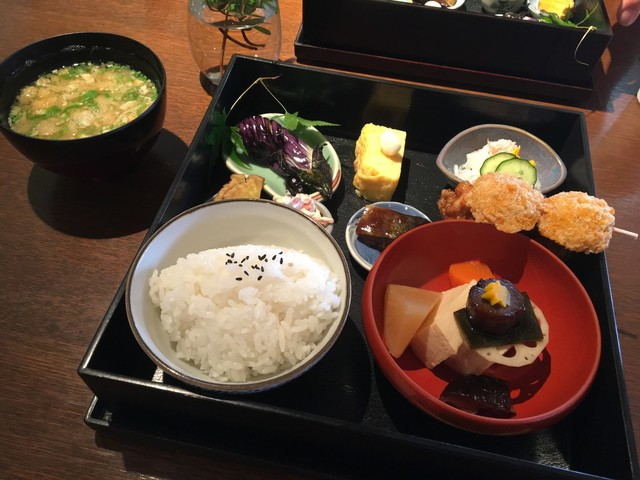

Food from *Hiroya ひろや*, the most expensive restaurant in the sample

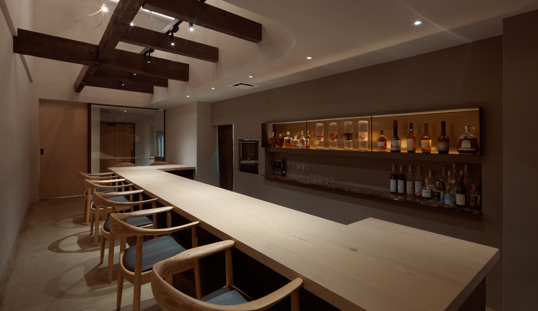

*Orto オルト*, the top rated restaurant in the sample

#### **Data Frame Creation**

*Converting dinner price and lunch price to factor vectors:*

```r
dinnerprice_factor<-as.factor(rest1$DinnerPrice)
dinnerprice_factor <- factor(rest1$DinnerPrice)
levels(dinnerprice_factor)
```

```
##  [1] " ～￥999"         "￥1000～￥1999"   "￥10000～￥14999"
##  [4] "￥15000～￥19999" "￥2000～￥2999"   "￥20000～￥29999"
##  [7] "￥3000～￥3999"   "￥4000～￥4999"   "￥5000～￥5999"
## [10] "￥6000～￥7999"   "￥8000～￥9999"
```

```r
lunchprice_factor<-as.factor(rest1$LunchPrice)
lunchprice_factor <- factor(rest1$LunchPrice)
levels(lunchprice_factor)
```

```
## [1] " ～￥999"         "￥1000～￥1999"   "￥15000～￥19999"
## [4] "￥2000～￥2999"   "￥3000～￥3999"   "￥4000～￥4999"
## [7] "￥5000～￥5999"   "￥6000～￥7999"
```

*Converting the dinnerprice_factor and lunchprice_factor to numeric vectors:*

```r
dinnerprice<-factor(dinnerprice_factor,levels=c("500", "1500", "2500", "3500", "4500", "5500", "7000", "9000", "12500", "17500", "25000"))

dinnerprice[dinnerprice_factor==" ～￥999"]<-"500"
dinnerprice[dinnerprice_factor=="￥1000～￥1999"]<-"1500"
dinnerprice[dinnerprice_factor=="￥2000～￥2999"]<-"2500"
dinnerprice[dinnerprice_factor=="￥3000～￥3999"]<-"3500"
dinnerprice[dinnerprice_factor=="￥4000～￥4999"]<-"4500"
dinnerprice[dinnerprice_factor=="￥5000～￥5999"]<-"5500"
dinnerprice[dinnerprice_factor=="￥6000～￥7999"]<-"7000"
dinnerprice[dinnerprice_factor=="￥8000～￥9999"]<-"9000"
dinnerprice[dinnerprice_factor=="￥10000～￥14999"]<-"12500"
dinnerprice[dinnerprice_factor=="￥15000～￥19999"]<-"17500"
dinnerprice[dinnerprice_factor=="￥20000～￥29999"]<-"25000"


summary(dinnerprice)
```

```
##   500  1500  2500  3500  4500  5500  7000  9000 12500 17500 25000
##     4     6     9    22    12     6     8     4     7     1     1
```

```r
dinnerprice<-as.numeric(as.character(dinnerprice))
is.numeric(dinnerprice)
```

```
## [1] TRUE
```

```r
dinnerprice
```

```
##  [1]  3500  3500  3500  9000  2500  3500  3500  4500  9000  4500  3500
## [12]  5500  3500  9000  3500  3500  3500 12500  3500  5500  3500 12500
## [23]  3500  5500 17500  1500  7000 12500  2500  3500  4500  3500  7000
## [34]  2500  7000  2500   500 12500 12500  3500  4500  9000  5500   500
## [45]  5500  7000  1500 12500  2500   500  4500  2500  1500  3500  4500
## [56]  2500  3500  1500  4500  1500 12500  2500  4500  1500  4500  7000
## [67]  4500  2500  7000  5500  3500  3500  7000  3500  4500 25000   500
## [78]  7000  4500  3500
```

```r
lunchprice<-factor(lunchprice_factor,levels=c("500", "1500", "2500", "3500", "4500", "5500", "7000", "17500"))

lunchprice[lunchprice_factor==" ～￥999"]<-"500"
lunchprice[lunchprice_factor=="￥1000～￥1999"]<-"1500"
lunchprice[lunchprice_factor=="￥2000～￥2999"]<-"2500"
lunchprice[lunchprice_factor=="￥3000～￥3999"]<-"3500"
lunchprice[lunchprice_factor=="￥4000～￥4999"]<-"4500"
lunchprice[lunchprice_factor=="￥5000～￥5999"]<-"5500"
lunchprice[lunchprice_factor=="￥6000～￥7999"]<-"7000"
lunchprice[lunchprice_factor=="￥15000～￥19999"]<-"17500"


summary(lunchprice)
```

```
##   500  1500  2500  3500  4500  5500  7000 17500
##    17    34    12     8     2     4     2     1
```

```r
lunchprice<-as.numeric(as.character(lunchprice))
is.numeric(lunchprice)
```

```
## [1] TRUE
```

```r
lunchprice
```

```
##  [1]   500  1500  2500  2500   500  2500   500  1500  2500  1500  1500
## [12]  1500  1500  4500  3500  1500  3500  4500  1500  1500  1500  5500
## [23]   500  2500 17500  1500  1500  7000   500   500  1500  1500  2500
## [34]  1500  3500  1500   500  5500  3500  1500  2500  1500  1500   500
## [45]  2500  1500  1500  5500  1500   500  2500   500  3500   500  1500
## [56]   500  2500   500  1500  1500  5500  1500  2500   500  1500  1500
## [67]  1500  1500  3500  2500  1500   500  3500   500  1500  7000   500
## [78]  3500  1500  1500
```

*Calculating average price for each restaurant:*

```r
Avg_Price <- (dinnerprice + lunchprice)/2
Avg_Price
```

```
##  [1]  2000  2500  3000  5750  1500  3000  2000  3000  5750  3000  2500
## [12]  3500  2500  6750  3500  2500  3500  8500  2500  3500  2500  9000
## [23]  2000  4000 17500  1500  4250  9750  1500  2000  3000  2500  4750
## [34]  2000  5250  2000   500  9000  8000  2500  3500  5250  3500   500
## [45]  4000  4250  1500  9000  2000   500  3500  1500  2500  2000  3000
## [56]  1500  3000  1000  3000  1500  9000  2000  3500  1000  3000  4250
## [67]  3000  2000  5250  4000  2500  2000  5250  2000  3000 16000   500
## [78]  5250  3000  2500
```

*Creating data frame:*

Data frame with the 80 restaurants’ average price and rating.

```r
Rating <- rest1$TotalRating

pricevsrating_df <- data.frame(Avg_Price, Rating)
pricevsrating_df
```

#### **Data Visualization**

I created a scatterplot of total rating vs average price with a best fit linear regression model. The correlation and coefficient of determination were calculated to be R=0.5194 and R^2=0.2698.

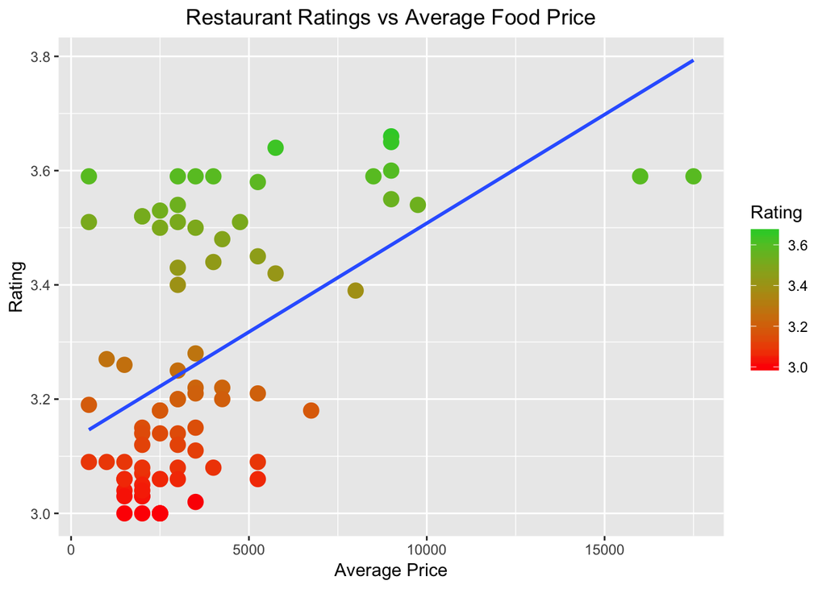

```r
ggplot(pricevsrating_df, aes(x=Avg_Price, y=Rating))+
  geom_point(size=4, aes(color=Rating))+
  scale_color_gradient(name="Rating", low="red", high="#32cd32")+
  labs(x="Average Price", y="Rating", title="Restaurant Ratings vs Average Food Price")+
  theme(plot.title = element_text(hjust = 0.5))+
  geom_smooth(method="lm", se = FALSE)
```

```r
lm(Avg_Price ~ Rating)
```

```
##
## Call:
## lm(formula = Avg_Price ~ Rating)
##
## Coefficients:
## (Intercept)       Rating
##      -19432         7089
```

*Correlation (R):*

```r
pricevsrating_df %>%
  summarize(r_2 = cor(Avg_Price, Rating))
```

```
##         r_2
## 1 0.5194219
```

*Coefficient of Determination (R^2):*

```r
lm_pvr <- lm(Avg_Price ~ Rating, data = pricevsrating_df)
summary(lm_pvr)
```

```
##
## Call:
## lm(formula = Avg_Price ~ Rating, data = pricevsrating_df)
##
## Residuals:
##     Min      1Q  Median      3Q     Max
## -5516.1  -975.4  -285.1   684.9 11483.9
##
## Coefficients:
##             Estimate Std. Error t value Pr(>|t|)
## (Intercept)   -19432       4327  -4.491 2.42e-05 ***
## Rating          7089       1320   5.368 7.94e-07 ***
## ---
## Signif. codes:  0 '***' 0.001 '**' 0.01 '*' 0.05 '.' 0.1 ' ' 1
##
## Residual standard error: 2578 on 78 degrees of freedom
## Multiple R-squared:  0.2698, Adjusted R-squared:  0.2604
## F-statistic: 28.82 on 1 and 78 DF,  p-value: 7.936e-07
```

```r
summary(lm_pvr)$r.squared
```

```
## [1] 0.2697991
```

#### **Analysis Without Average Price Outliers**

In this section, I used the 1.5*IQR rule to take out outliers in terms of average price and created a new scatterplot using the new data frame that did not contain these outliers. The recalculated R and R^2 values are 0.2827 and 0.0799, respectively.

*Outliers in Average Price:*

The third quartile is 4250, which was added to the value of 1.5*IQR. Outliers for average price are the values where Avg_Price > 7625.

```r
quantile(Avg_Price)
```

```
##    0%   25%   50%   75%  100%
##   500  2000  3000  4250 17500
```

```r
IQR_AP = IQR(Avg_Price)
IQR_AP
```

```
## [1] 2250
```

```r
1.5*IQR_AP
```

```
## [1] 3375
```

```r
4250+1.5*IQR_AP
```

```
## [1] 7625
```

*New Data Frame and Visualization:*

This new data frame contains all the data points with average price values less than 7625. The new scatterplot shows the values of the `pricevsrating` data frame without outliers.

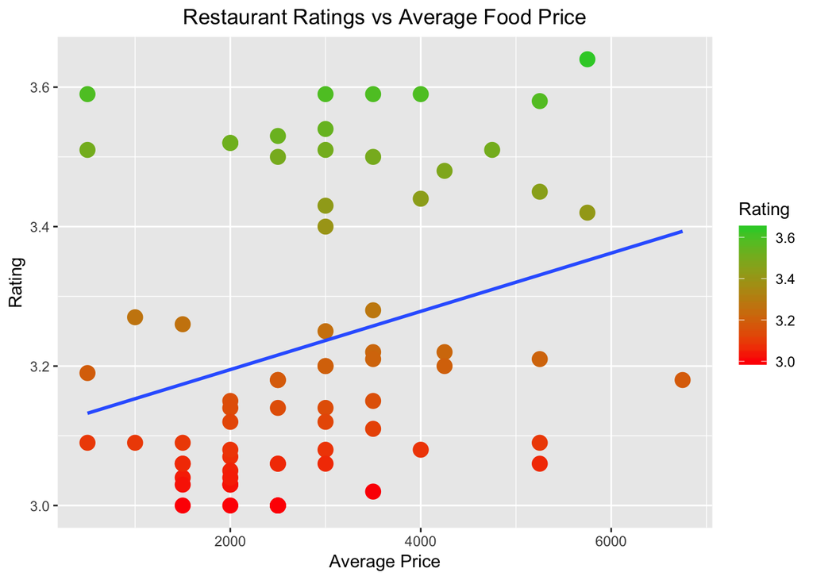

```r
pricevsrating_df2 <- pricevsrating_df %>%
  filter(Avg_Price <= 7625)

ggplot(pricevsrating_df2, aes(x=Avg_Price, y=Rating))+
  geom_point(size=4, aes(color=Rating))+
  scale_color_gradient(name="Rating", low="red", high="#32cd32")+
  labs(x="Average Price", y="Rating", title="Restaurant Ratings vs Average Food Price")+
  theme(plot.title = element_text(hjust = 0.5))+
  geom_smooth(method="lm", se = FALSE)
```

*New Correlation (R) and Coefficient of Determination (R^2)*

```r
pricevsrating_df2 %>%
  summarize(r_3 = cor(Avg_Price, Rating))
```

```
##         r_3
## 1 0.2826657
```

```r
lm_pvr2 <- lm(Avg_Price ~ Rating, data = pricevsrating_df2)
summary(lm_pvr2)
```

```
##
## Call:
## lm(formula = Avg_Price ~ Rating, data = pricevsrating_df2)
##
## Residuals:
##     Min      1Q  Median      3Q     Max
## -3059.3  -707.9   -59.3   658.2  3975.1
##
## Coefficients:
##             Estimate Std. Error t value Pr(>|t|)
## (Intercept)  -3309.2     2530.5  -1.308   0.1953
## Rating        1913.2      781.6   2.448   0.0169 *
## ---
## Signif. codes:  0 '***' 0.001 '**' 0.01 '*' 0.05 '.' 0.1 ' ' 1
##
## Residual standard error: 1315 on 69 degrees of freedom
## Multiple R-squared:  0.0799, Adjusted R-squared:  0.06657
## F-statistic: 5.992 on 1 and 69 DF,  p-value: 0.01692
```

```r
summary(lm_pvr2)$r.squared
```

```
## [1] 0.07989992
```

### Part 2: Does a Lunch to Dinner Price Increase Mean Better Food Quality for Dinner? (Difference in Lunch and Dinner Prices vs Difference in Lunch and Dinner Ratings)

Part 2 deals with the relationship between the difference in food quality and ratings for lunch vs dinner. The difference between dinner and lunch prices and the difference in dinner and lunch ratings were calculated for each restaurant. A data frame with the dinner and lunch price and rating differences was created.

*Calculating the price and rating difference between dinner and lunch:*

```r
pricediff <- dinnerprice - lunchprice
pricediff
```

```
##  [1]  3000  2000  1000  6500  2000  1000  3000  3000  6500  3000  2000
## [12]  4000  2000  4500     0  2000     0  8000  2000  4000  2000  7000
## [23]  3000  3000     0     0  5500  5500  2000  3000  3000  2000  4500
## [34]  1000  3500  1000     0  7000  9000  2000  2000  7500  4000     0
## [45]  3000  5500     0  7000  1000     0  2000  2000 -2000  3000  3000
## [56]  2000  1000  1000  3000     0  7000  1000  2000  1000  3000  5500
## [67]  3000  1000  3500  3000  2000  3000  3500  3000  3000 18000     0
## [78]  3500  3000  2000
```

```r
ratingdiff <- rest1$DinnerRating - rest1$LunchRating
ratingdiff
```

```
##  [1]  0.18  0.00 -0.10  0.04 -0.12  0.21  0.09 -0.17  0.08 -0.11 -0.14
## [12] -0.04 -0.03 -0.39 -0.34  0.00  0.03  0.53 -0.08  0.16 -0.03  0.01
## [23]  0.00 -0.11  0.02  0.02 -0.35  0.04  0.00 -0.01 -0.43 -0.26 -0.21
## [34]  0.05  0.01 -0.04 -0.03  0.01  0.39  0.01 -0.03  0.20 -0.08 -0.11
## [45]  0.31 -0.15  0.05 -0.14 -0.24 -0.01 -0.33  0.00  0.35  0.02  0.13
## [56]  0.06 -0.06 -0.02  0.02 -0.01  0.11 -0.12 -0.23 -0.07  0.18  0.16
## [67]  0.06  0.05 -0.01 -0.03  0.01  0.01  0.00  0.21 -0.14 -0.10  0.04
## [78]  0.15 -0.01 -0.24
```

*Creating data frame:*

```r
PvRdifference_df <- data.frame(pricediff, ratingdiff)
PvRdifference_df
```

#### **Data Visualization**

I created a scatterplot of rating difference vs price difference with a best fit linear regression model. The correlation and coefficient of determination were calculated to be R=0.1275 and R^2=0.0.0163.

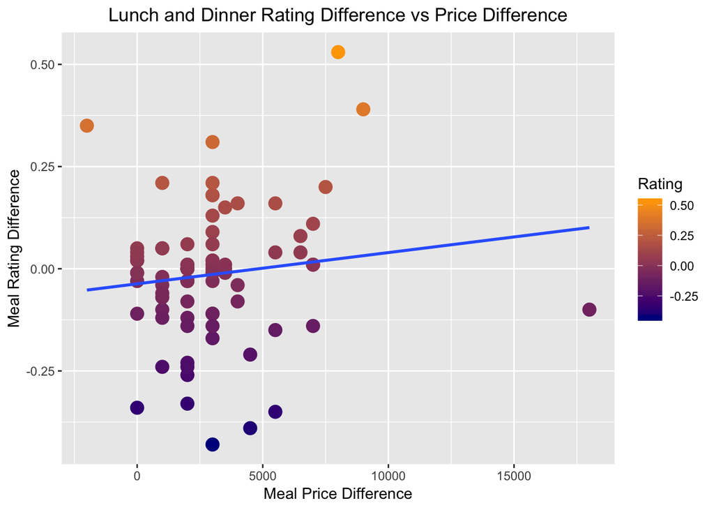

```r
ggplot(PvRdifference_df, aes(x=pricediff, y=ratingdiff))+
  geom_point(size=4, aes(color=ratingdiff))+
  scale_color_gradient(name="Rating", low="darkblue", high="orange")+
  labs(x="Meal Price Difference", y="Meal Rating Difference", title="Lunch and Dinner Rating Difference vs Price Difference")+
  theme(plot.title = element_text(hjust = 0.5))+
  geom_smooth(method="lm", se = FALSE)
```

```r
lm(pricediff ~ ratingdiff)
```

```
##
## Call:
## lm(formula = pricediff ~ ratingdiff)
##
## Coefficients:
## (Intercept)   ratingdiff
##        3024         2126
```

*Correlation (R):*

```r
PvRdifference_df %>%
  summarize(r_4 = cor(pricediff, ratingdiff))
```

```
##         r_4
## 1 0.1274855
```

*Coefficient of Determination (R^2):*

```r
lmpvrdiff <- lm(pricediff ~ ratingdiff, data = PvRdifference_df)
summary(lmpvrdiff)
```

```
##
## Call:
## lm(formula = pricediff ~ ratingdiff, data = PvRdifference_df)
##
## Residuals:
##     Min      1Q  Median      3Q     Max
## -5767.7 -1577.0  -406.3   532.4 15189.1
##
## Coefficients:
##             Estimate Std. Error t value Pr(>|t|)
## (Intercept)   3023.5      308.7   9.793 3.15e-15 ***
## ratingdiff    2126.3     1873.1   1.135     0.26
## ---
## Signif. codes:  0 '***' 0.001 '**' 0.01 '*' 0.05 '.' 0.1 ' ' 1
##
## Residual standard error: 2751 on 78 degrees of freedom
## Multiple R-squared:  0.01625,    Adjusted R-squared:  0.00364
## F-statistic: 1.289 on 1 and 78 DF,  p-value: 0.2598
```

```r
summary(lmpvrdiff)$r.squared
```

```
## [1] 0.01625256
```

#### **Analysis Without Price Difference Outliers**

Like in Part 1 of Section 2, I used the 1.5*IQR rule to take out outliers of price difference and created a new scatterplot using the new data frame that does not contain the outliers. The recalculated R and R^2 values are -0.0312 and 0.0010, respectively.

*Outliers in Price Difference:*

The third quartile is 3500, which was added to the value of 1.5*IQR. Outliers for price difference are the values where pricediff > 7250.

```r
quantile(pricediff)
```

```
##    0%   25%   50%   75%  100%
## -2000  1000  3000  3500 18000
```

```r
IQR_PD = IQR(pricediff)
IQR_PD
```

```
## [1] 2500
```

```r
1.5*IQR_PD
```

```
## [1] 3750
```

```r
3500+1.5*IQR_PD
```

```
## [1] 7250
```

*New Data Frame and Visualization:*

This new data frame contains the data points with price difference values less than 7250. The new scatterplot shows the values of the `PvRdifference` data frame without outliers.

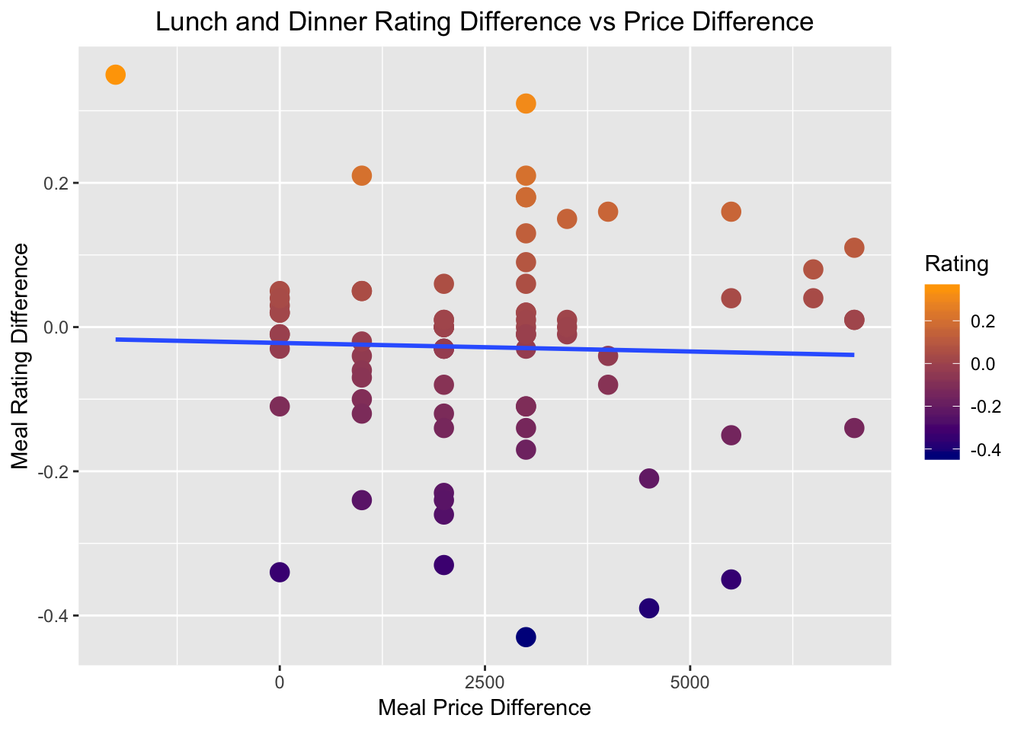

```r
PvRdifference_df2 <- PvRdifference_df %>%
  filter(pricediff <= 7250)

ggplot(PvRdifference_df2, aes(x=pricediff, y=ratingdiff))+
  geom_point(size=4, aes(color=ratingdiff))+
  scale_color_gradient(name="Rating", low="darkblue", high="orange")+
  labs(x="Meal Price Difference", y="Meal Rating Difference", title="Lunch and Dinner Rating Difference vs Price Difference")+
  theme(plot.title = element_text(hjust = 0.5))+
  geom_smooth(method="lm", se = FALSE)
```

*New Correlation (R) and Coefficient of Determination (R^2)*

```r
PvRdifference_df2 %>%
  summarize(r_5 = cor(pricediff, ratingdiff))
```

```
##           r_5
## 1 -0.03118658
```

```r
lmpvrdiff2 <- lm(pricediff ~ ratingdiff, data = PvRdifference_df2)
summary(lmpvrdiff2)
```

```
##
## Call:
## lm(formula = pricediff ~ ratingdiff, data = PvRdifference_df2)
##
## Residuals:
##     Min      1Q  Median      3Q     Max
## -4437.2 -1560.1  -156.4   638.7  4464.5
##
## Coefficients:
##             Estimate Std. Error t value Pr(>|t|)
## (Intercept)   2580.6      227.7  11.335   <2e-16 ***
## ratingdiff    -409.7     1526.5  -0.268    0.789
## ---
## Signif. codes:  0 '***' 0.001 '**' 0.01 '*' 0.05 '.' 0.1 ' ' 1
##
## Residual standard error: 1949 on 74 degrees of freedom
## Multiple R-squared:  0.0009726,  Adjusted R-squared:  -0.01253
## F-statistic: 0.07204 on 1 and 74 DF,  p-value: 0.7891
```

```r
summary(lmpvrdiff2)$r.squared
```

```
## [1] 0.0009726028
```

## Interpretations of Data and Overall Conclusions

*Section 1*

In Section 1, we saw that there exists a weak linear relationship between average price and rating for the 27 restaurants from the survey I sent out to my friends.

*Section 2*

In Part 1, the first scatterplot, which included outliers, had a correlation of 0.5194 and R^2=0.2698. Thus, there is a moderately strong, positive correlation between average price and rating. However, after the outliers were taken out, both the correlation and coefficient of determination decreased to 0.2827 and 0.0799, respectively, indicating a weaker linear relationship. For both graphs, the R^2 values were extremely low, so not much variability was accounted for by the linear models.

In Part 2, the first scatterplot had a weak, positive correlation of 0.1275 and R^2 value of 0.0163. Similar to the results from Part 1, after outliers were taken out, correlation and coefficient of determination both decreased significantly to -0.0312 and 0.0010, respectively. It is interesting to note that after excluding outliers, the correlation became negative. Once again, the coefficient of determination was very small regardless of whether or not we included outliers.